```python
import numpy as np
import pandas as pd
from collections import Counter
from numpy import random
import os
import scipy
from scipy import stats
from matplotlib import pyplot as plt
from scipy.stats import binom
from scipy.stats import poisson
from scipy.stats import norm, t
import seaborn as sns
import pylab
from pylab import legend, plot, show, title, xlabel, ylabel
from random import choice
import matplotlib
import statsmodels
from statsmodels import stats
from statsmodels.stats import weightstats as ssw

import statsmodels.api as sm
from statsmodels.formula.api import ols
import statsmodels.stats.multicomp
from statsmodels.stats import proportion as ssp

from scipy.stats import chisquare
from scipy.stats import chi2_contingency
from scipy.stats import pearsonr
```

```python
os.chdir(r'C:\Users\Admin\Downloads')
```

# Loading the previous application dataset

```python
df_prev=pd.read_csv('previous_application.csv')
df_prev.info()
```

```
<class 'pandas.core.frame.DataFrame'>
RangeIndex: 1670214 entries, 0 to 1670213
Data columns (total 37 columns):
 #   Column                       Non-Null Count    Dtype
---  ------                       --------------    -----
 0   SK_ID_PREV                   1670214 non-null  int64
 1   SK_ID_CURR                   1670214 non-null  int64
 2   NAME_CONTRACT_TYPE           1670214 non-null  object
 3   AMT_ANNUITY                  1297979 non-null  float64
 4   AMT_APPLICATION              1670214 non-null  float64
 5   AMT_CREDIT                   1670213 non-null  float64
 6   AMT_DOWN_PAYMENT             774370 non-null   float64
 7   AMT_GOODS_PRICE              1284699 non-null  float64
 8   WEEKDAY_APPR_PROCESS_START   1670214 non-null  object
 9   HOUR_APPR_PROCESS_START      1670214 non-null  int64
```

[output cut: 29 more lines]

```python
df_prev.head()
```

|  | SK_ID_PREV | SK_ID_CURR | NAME_CONTRACT_TYPE | AMT_ANNUITY | AMT_APPLICATION | AMT_CREDIT | AMT_DOWN_PAYMENT | AMT_GOODS_PRICE | WEEKDAY_APPR_PROCESS_START | HOUR_APPR_PROCESS_START | ... | NAME_SELLER_INDUSTRY | CNT_PAYMENT | NAME_YIELD_GROUP | PRODUCT_COMBINATION | DAYS_FIRST_DRAWING | DAYS_FIRST_DUE | DAYS_LAST_DUE_1ST_VERSION | DAYS_LAST_DUE | DAYS_TERMINATION | NFLAG_INSURED_ON_APPROVAL |
| --- | --- | --- | --- | --- | --- | --- | --- | --- | --- | --- | --- | --- | --- | --- | --- | --- | --- | --- | --- | --- | --- |
| 0 | 2030495 | 271877 | Consumer loans | 1730.430 | 17145.0 | 17145.0 | 0.0 | 17145.0 | SATURDAY | 15 | ... | Connectivity | 12.0 | middle | POS mobile with interest | 365243.0 | -42.0 | 300.0 | -42.0 | -37.0 | 0.0 |
| 1 | 2802425 | 108129 | Cash loans | 25188.615 | 607500.0 | 679671.0 | NaN | 607500.0 | THURSDAY | 11 | ... | XNA | 36.0 | low_action | Cash X-Sell: low | 365243.0 | -134.0 | 916.0 | 365243.0 | 365243.0 | 1.0 |
| 2 | 2523466 | 122040 | Cash loans | 15060.735 | 112500.0 | 136444.5 | NaN | 112500.0 | TUESDAY | 11 | ... | XNA | 12.0 | high | Cash X-Sell: high | 365243.0 | -271.0 | 59.0 | 365243.0 | 365243.0 | 1.0 |
| 3 | 2819243 | 176158 | Cash loans | 47041.335 | 450000.0 | 470790.0 | NaN | 450000.0 | MONDAY | 7 | ... | XNA | 12.0 | middle | Cash X-Sell: middle | 365243.0 | -482.0 | -152.0 | -182.0 | -177.0 | 1.0 |
| 4 | 1784265 | 202054 | Cash loans | 31924.395 | 337500.0 | 404055.0 | NaN | 337500.0 | THURSDAY | 9 | ... | XNA | 24.0 | high | Cash Street: high | NaN | NaN | NaN | NaN | NaN | NaN |

5 rows × 37 columns

# Loading the application data dataset

```python
df_app=pd.read_csv('application_data.csv')
df_app.info()
```

```
<class 'pandas.core.frame.DataFrame'>
RangeIndex: 307511 entries, 0 to 307510
Columns: 122 entries, SK_ID_CURR to AMT_REQ_CREDIT_BUREAU_YEAR
dtypes: float64(65), int64(41), object(16)
memory usage: 286.2+ MB
```

```python
df_app.head(10)
```

|  | SK_ID_CURR | TARGET | NAME_CONTRACT_TYPE | CODE_GENDER | FLAG_OWN_CAR | FLAG_OWN_REALTY | CNT_CHILDREN | AMT_INCOME_TOTAL | AMT_CREDIT | AMT_ANNUITY | ... | FLAG_DOCUMENT_18 | FLAG_DOCUMENT_19 | FLAG_DOCUMENT_20 | FLAG_DOCUMENT_21 | AMT_REQ_CREDIT_BUREAU_HOUR | AMT_REQ_CREDIT_BUREAU_DAY | AMT_REQ_CREDIT_BUREAU_WEEK | AMT_REQ_CREDIT_BUREAU_MON | AMT_REQ_CREDIT_BUREAU_QRT | AMT_REQ_CREDIT_BUREAU_YEAR |
| --- | --- | --- | --- | --- | --- | --- | --- | --- | --- | --- | --- | --- | --- | --- | --- | --- | --- | --- | --- | --- | --- |
| 0 | 100002 | 1 | Cash loans | M | N | Y | 0 | 202500.0 | 406597.5 | 24700.5 | ... | 0 | 0 | 0 | 0 | 0.0 | 0.0 | 0.0 | 0.0 | 0.0 | 1.0 |
| 1 | 100003 | 0 | Cash loans | F | N | N | 0 | 270000.0 | 1293502.5 | 35698.5 | ... | 0 | 0 | 0 | 0 | 0.0 | 0.0 | 0.0 | 0.0 | 0.0 | 0.0 |
| 2 | 100004 | 0 | Revolving loans | M | Y | Y | 0 | 67500.0 | 135000.0 | 6750.0 | ... | 0 | 0 | 0 | 0 | 0.0 | 0.0 | 0.0 | 0.0 | 0.0 | 0.0 |
| 3 | 100006 | 0 | Cash loans | F | N | Y | 0 | 135000.0 | 312682.5 | 29686.5 | ... | 0 | 0 | 0 | 0 | NaN | NaN | NaN | NaN | NaN | NaN |
| 4 | 100007 | 0 | Cash loans | M | N | Y | 0 | 121500.0 | 513000.0 | 21865.5 | ... | 0 | 0 | 0 | 0 | 0.0 | 0.0 | 0.0 | 0.0 | 0.0 | 0.0 |
| 5 | 100008 | 0 | Cash loans | M | N | Y | 0 | 99000.0 | 490495.5 | 27517.5 | ... | 0 | 0 | 0 | 0 | 0.0 | 0.0 | 0.0 | 0.0 | 1.0 | 1.0 |
| 6 | 100009 | 0 | Cash loans | F | Y | Y | 1 | 171000.0 | 1560726.0 | 41301.0 | ... | 0 | 0 | 0 | 0 | 0.0 | 0.0 | 0.0 | 1.0 | 1.0 | 2.0 |
| 7 | 100010 | 0 | Cash loans | M | Y | Y | 0 | 360000.0 | 1530000.0 | 42075.0 | ... | 0 | 0 | 0 | 0 | 0.0 | 0.0 | 0.0 | 0.0 | 0.0 | 0.0 |
| 8 | 100011 | 0 | Cash loans | F | N | Y | 0 | 112500.0 | 1019610.0 | 33826.5 | ... | 0 | 0 | 0 | 0 | 0.0 | 0.0 | 0.0 | 0.0 | 0.0 | 1.0 |
| 9 | 100012 | 0 | Revolving loans | M | N | Y | 0 | 135000.0 | 405000.0 | 20250.0 | ... | 0 | 0 | 0 | 0 | NaN | NaN | NaN | NaN | NaN | NaN |

10 rows × 122 columns

```python
df_app.columns
```

```
Index(['SK_ID_CURR', 'TARGET', 'NAME_CONTRACT_TYPE', 'CODE_GENDER',
       'FLAG_OWN_CAR', 'FLAG_OWN_REALTY', 'CNT_CHILDREN', 'AMT_INCOME_TOTAL',
       'AMT_CREDIT', 'AMT_ANNUITY',
       ...
       'FLAG_DOCUMENT_18', 'FLAG_DOCUMENT_19', 'FLAG_DOCUMENT_20',
       'FLAG_DOCUMENT_21', 'AMT_REQ_CREDIT_BUREAU_HOUR',
       'AMT_REQ_CREDIT_BUREAU_DAY', 'AMT_REQ_CREDIT_BUREAU_WEEK',
       'AMT_REQ_CREDIT_BUREAU_MON', 'AMT_REQ_CREDIT_BUREAU_QRT',
       'AMT_REQ_CREDIT_BUREAU_YEAR'],
      dtype='object', length=122)
```

```python
len(df_prev),len(df_app)
```

```
(1670214, 307511)
```

```python
null_prev = df_prev.isnull().sum()
print(null_prev)
```

```
SK_ID_PREV                           0
SK_ID_CURR                           0
NAME_CONTRACT_TYPE                   0
AMT_ANNUITY                     372235
AMT_APPLICATION                      0
AMT_CREDIT                           1
AMT_DOWN_PAYMENT                895844
AMT_GOODS_PRICE                 385515
WEEKDAY_APPR_PROCESS_START           0
HOUR_APPR_PROCESS_START              0
FLAG_LAST_APPL_PER_CONTRACT          0
NFLAG_LAST_APPL_IN_DAY               0
RATE_DOWN_PAYMENT               895844
RATE_INTEREST_PRIMARY          1664263
RATE_INTEREST_PRIVILEGED       1664263
NAME_CASH_LOAN_PURPOSE               0
NAME_CONTRACT_STATUS                 0
DAYS_DECISION                        0
NAME_PAYMENT_TYPE                    0
CODE_REJECT_REASON                   0
NAME_TYPE_SUITE                 820405
NAME_CLIENT_TYPE                     0
NAME_GOODS_CATEGORY                  0
NAME_PORTFOLIO                       0
NAME_PRODUCT_TYPE                    0
CHANNEL_TYPE                         0
SELLERPLACE_AREA                     0
NAME_SELLER_INDUSTRY                 0
CNT_PAYMENT                     372230
NAME_YIELD_GROUP                     0
PRODUCT_COMBINATION                346
DAYS_FIRST_DRAWING              673065
DAYS_FIRST_DUE                  673065
DAYS_LAST_DUE_1ST_VERSION       673065
DAYS_LAST_DUE                   673065
DAYS_TERMINATION                673065
NFLAG_INSURED_ON_APPROVAL       673065
dtype: int64
```

```python
null_app = df_prev.isnull().sum()
print(null_app)
```

```
SK_ID_PREV                           0
SK_ID_CURR                           0
NAME_CONTRACT_TYPE                   0
AMT_ANNUITY                     372235
AMT_APPLICATION                      0
AMT_CREDIT                           1
AMT_DOWN_PAYMENT                895844
AMT_GOODS_PRICE                 385515
WEEKDAY_APPR_PROCESS_START           0
HOUR_APPR_PROCESS_START              0
FLAG_LAST_APPL_PER_CONTRACT          0
NFLAG_LAST_APPL_IN_DAY               0
RATE_DOWN_PAYMENT               895844
RATE_INTEREST_PRIMARY          1664263
RATE_INTEREST_PRIVILEGED       1664263
NAME_CASH_LOAN_PURPOSE               0
NAME_CONTRACT_STATUS                 0
DAYS_DECISION                        0
NAME_PAYMENT_TYPE                    0
CODE_REJECT_REASON                   0
NAME_TYPE_SUITE                 820405
NAME_CLIENT_TYPE                     0
NAME_GOODS_CATEGORY                  0
NAME_PORTFOLIO                       0
NAME_PRODUCT_TYPE                    0
CHANNEL_TYPE                         0
SELLERPLACE_AREA                     0
NAME_SELLER_INDUSTRY                 0
CNT_PAYMENT                     372230
NAME_YIELD_GROUP                     0
PRODUCT_COMBINATION                346
DAYS_FIRST_DRAWING              673065
DAYS_FIRST_DUE                  673065
DAYS_LAST_DUE_1ST_VERSION       673065
DAYS_LAST_DUE                   673065
DAYS_TERMINATION                673065
NFLAG_INSURED_ON_APPROVAL       673065
dtype: int64
```

# Concating the two CSV files using an inner join to establish a connection between SK_ID_CURR and SK_ID_PREV for better analysis.

Here ,We are merging the datasets using an inner join because the problem statement requires us to determine whether individuals who have taken loans from the bank (both current and previous loans) are able to repay them or not.

```python
merged_df = pd.concat([df_prev,df_app],axis=1,join="inner")
```

```python
merged_df
```

|  | SK_ID_PREV | SK_ID_CURR | NAME_CONTRACT_TYPE | AMT_ANNUITY | AMT_APPLICATION | AMT_CREDIT | AMT_DOWN_PAYMENT | AMT_GOODS_PRICE | WEEKDAY_APPR_PROCESS_START | HOUR_APPR_PROCESS_START | ... | FLAG_DOCUMENT_18 | FLAG_DOCUMENT_19 | FLAG_DOCUMENT_20 | FLAG_DOCUMENT_21 | AMT_REQ_CREDIT_BUREAU_HOUR | AMT_REQ_CREDIT_BUREAU_DAY | AMT_REQ_CREDIT_BUREAU_WEEK | AMT_REQ_CREDIT_BUREAU_MON | AMT_REQ_CREDIT_BUREAU_QRT | AMT_REQ_CREDIT_BUREAU_YEAR |
| --- | --- | --- | --- | --- | --- | --- | --- | --- | --- | --- | --- | --- | --- | --- | --- | --- | --- | --- | --- | --- | --- |
| 0 | 2030495 | 271877 | Consumer loans | 1730.430 | 17145.0 | 17145.0 | 0.0 | 17145.0 | SATURDAY | 15 | ... | 0 | 0 | 0 | 0 | 0.0 | 0.0 | 0.0 | 0.0 | 0.0 | 1.0 |
| 1 | 2802425 | 108129 | Cash loans | 25188.615 | 607500.0 | 679671.0 | NaN | 607500.0 | THURSDAY | 11 | ... | 0 | 0 | 0 | 0 | 0.0 | 0.0 | 0.0 | 0.0 | 0.0 | 0.0 |
| 2 | 2523466 | 122040 | Cash loans | 15060.735 | 112500.0 | 136444.5 | NaN | 112500.0 | TUESDAY | 11 | ... | 0 | 0 | 0 | 0 | 0.0 | 0.0 | 0.0 | 0.0 | 0.0 | 0.0 |
| 3 | 2819243 | 176158 | Cash loans | 47041.335 | 450000.0 | 470790.0 | NaN | 450000.0 | MONDAY | 7 | ... | 0 | 0 | 0 | 0 | NaN | NaN | NaN | NaN | NaN | NaN |
| 4 | 1784265 | 202054 | Cash loans | 31924.395 | 337500.0 | 404055.0 | NaN | 337500.0 | THURSDAY | 9 | ... | 0 | 0 | 0 | 0 | 0.0 | 0.0 | 0.0 | 0.0 | 0.0 | 0.0 |
| ... | ... | ... | ... | ... | ... | ... | ... | ... | ... | ... | ... | ... | ... | ... | ... | ... | ... | ... | ... | ... | ... |
| 307506 | 2510843 | 258664 | Cash loans | NaN | 0.0 | 0.0 | NaN | NaN | TUESDAY | 11 | ... | 0 | 0 | 0 | 0 | NaN | NaN | NaN | NaN | NaN | NaN |
| 307507 | 1386044 | 446476 | Cash loans | 18212.805 | 157500.0 | 167895.0 | NaN | 157500.0 | WEDNESDAY | 18 | ... | 0 | 0 | 0 | 0 | NaN | NaN | NaN | NaN | NaN | NaN |
| 307508 | 2116355 | 440338 | Cash loans | 26316.945 | 450000.0 | 491580.0 | NaN | 450000.0 | WEDNESDAY | 12 | ... | 0 | 0 | 0 | 0 | 1.0 | 0.0 | 0.0 | 1.0 | 0.0 | 1.0 |
| 307509 | 2430880 | 134252 | Cash loans | NaN | 0.0 | 0.0 | NaN | NaN | TUESDAY | 18 | ... | 0 | 0 | 0 | 0 | 0.0 | 0.0 | 0.0 | 0.0 | 0.0 | 0.0 |
| 307510 | 2605265 | 118869 | Cash loans | 24277.320 | 450000.0 | 533160.0 | NaN | 450000.0 | THURSDAY | 14 | ... | 0 | 0 | 0 | 0 | 0.0 | 0.0 | 0.0 | 2.0 | 0.0 | 1.0 |

307511 rows × 159 columns

# Next, we will drop the columns that are not essential for our current analysis.

Here, I am removing the SK_ID_PREV, SK_ID_CURR, FLAG_DOCUMENT, and DAY_OF_LOAN_PROCESS columns because I believe they are unnecessary for the EDA analysis. These columns don't provide direct insights for the current analysis, so I am excluding them to focus on the relevant data.

```python
merged_df.columns
```

```
Index(['SK_ID_PREV', 'SK_ID_CURR', 'NAME_CONTRACT_TYPE', 'AMT_ANNUITY',
       'AMT_APPLICATION', 'AMT_CREDIT', 'AMT_DOWN_PAYMENT', 'AMT_GOODS_PRICE',
       'WEEKDAY_APPR_PROCESS_START', 'HOUR_APPR_PROCESS_START',
       ...
       'FLAG_DOCUMENT_18', 'FLAG_DOCUMENT_19', 'FLAG_DOCUMENT_20',
       'FLAG_DOCUMENT_21', 'AMT_REQ_CREDIT_BUREAU_HOUR',
       'AMT_REQ_CREDIT_BUREAU_DAY', 'AMT_REQ_CREDIT_BUREAU_WEEK',
       'AMT_REQ_CREDIT_BUREAU_MON', 'AMT_REQ_CREDIT_BUREAU_QRT',
       'AMT_REQ_CREDIT_BUREAU_YEAR'],
      dtype='object', length=159)
```

```python
print(merged_df.columns.duplicated())
merged_df = merged_df.loc[:, ~merged_df.columns.duplicated()]
```

```
[False False False False False False False False False False False False
 False False False False False False False False False False False False
 False False False False False False False False False False False False
 False  True False  True False False False False False  True  True  True
  True False False False False False False False False False False False
 False False False False False False False False False  True  True False
 False False False False False False False False False False False False
 False False False False False False False False False False False False
 False False False False False False False False False False False False
 False False False False False False False False False False False False
 False False False False False False False False False False False False
 False False False False False False False False False False False False
 False False False False False False False False False False False False
 False False False]
```

```python
new_merged_df = pd.DataFrame(merged_df,columns=["NAME_CONTRACT_TYPE",'AMT_ANNUITY','TARGET','AMT_CREDIT','AMT_DOWN_PAYMENT','AMT_GOODS_PRICE', 'NAME_CASH_LOAN_PURPOSE','NAME_INCOME_TYPE','NAME_HOUSING_TYPE','CODE_REJECT_REASON'])
```

```python
new_merged_df
```

|  | NAME_CONTRACT_TYPE | AMT_ANNUITY | TARGET | AMT_CREDIT | AMT_DOWN_PAYMENT | AMT_GOODS_PRICE | NAME_CASH_LOAN_PURPOSE | NAME_INCOME_TYPE | NAME_HOUSING_TYPE | CODE_REJECT_REASON |
| --- | --- | --- | --- | --- | --- | --- | --- | --- | --- | --- |
| 0 | Consumer loans | 1730.430 | 1 | 17145.0 | 0.0 | 17145.0 | XAP | Working | House / apartment | XAP |
| 1 | Cash loans | 25188.615 | 0 | 679671.0 | NaN | 607500.0 | XNA | State servant | House / apartment | XAP |
| 2 | Cash loans | 15060.735 | 0 | 136444.5 | NaN | 112500.0 | XNA | Working | House / apartment | XAP |
| 3 | Cash loans | 47041.335 | 0 | 470790.0 | NaN | 450000.0 | XNA | Working | House / apartment | XAP |
| 4 | Cash loans | 31924.395 | 0 | 404055.0 | NaN | 337500.0 | Repairs | Working | House / apartment | HC |
| ... | ... | ... | ... | ... | ... | ... | ... | ... | ... | ... |
| 307506 | Cash loans | NaN | 0 | 0.0 | NaN | NaN | XNA | Working | With parents | XAP |
| 307507 | Cash loans | 18212.805 | 0 | 167895.0 | NaN | 157500.0 | XNA | Pensioner | House / apartment | XAP |
| 307508 | Cash loans | 26316.945 | 0 | 491580.0 | NaN | 450000.0 | XNA | Working | House / apartment | XAP |
| 307509 | Cash loans | NaN | 1 | 0.0 | NaN | NaN | XNA | Commercial associate | House / apartment | XAP |
| 307510 | Cash loans | 24277.320 | 0 | 533160.0 | NaN | 450000.0 | XNA | Commercial associate | House / apartment | XAP |

307511 rows × 10 columns

Columns to Drop:

Some columns may not be useful for your analysis or could be removed because they are redundant, have too many missing values, or are not relevant to your specific analysis. Here's a simple list of columns to consider removing:

Hashed or Unique Identifiers:

SK_ID_PREV, SK_ID_CURR: These are unique identifiers that don't help predict outcomes, so they can be dropped. Non-informative Columns:

NFLAG_LAST_APPL_IN_DAY: This might be similar to other features, so it's better to drop it. FLAG_LAST_APPL_PER_CONTRACT: It might be related to multiple applications, so it could be dropped for simplicity. NFLAG_MICRO_CASH: If micro-loans are not the focus, this column might not be useful. Columns with Too Many Missing Values:

If columns like SELLERPLACE_AREA or NAME_SELLER_INDUSTRY have too many missing values and are not important, they can be dropped. Columns with Too Many Categories:

PRODUCT_COMBINATION, NAME_YIELD_GROUP, NAME_PAYMENT_TYPE: If these are not essential for your analysis, they can be removed unless they add valuable insights. Final Considerations:

Missing Values: Check for missing values and decide whether to fill them (e.g., using the mean, median, or mode) or remove the rows/columns. Outliers: Some features like AMT_APPLICATION, AMT_CREDIT, and AMT_GOODS_PRICE might have extreme values, so you may need to handle these outliers before applying machine learning models.

```python
new_merged_df.isnull().sum()
```

```
NAME_CONTRACT_TYPE             0
AMT_ANNUITY                66847
TARGET                         0
AMT_CREDIT                     0
AMT_DOWN_PAYMENT          159975
AMT_GOODS_PRICE            68968
NAME_CASH_LOAN_PURPOSE         0
NAME_INCOME_TYPE               0
NAME_HOUSING_TYPE              0
CODE_REJECT_REASON             0
dtype: int64
```

```python
new_merged_df["CODE_REJECT_REASON"].unique()
```

```
array(['XAP', 'HC', 'LIMIT', 'CLIENT', 'SCOFR', 'SCO', 'XNA', 'VERIF',
       'SYSTEM'], dtype=object)
```

```python
new_merged_df["NAME_CASH_LOAN_PURPOSE"].unique()
```

```
array(['XAP', 'XNA', 'Repairs', 'Everyday expenses', 'Car repairs',
       'Building a house or an annex', 'Other', 'Journey',
       'Purchase of electronic equipment', 'Medicine',
       'Payments on other loans', 'Urgent needs', 'Buying a used car',
       'Buying a new car', 'Buying a holiday home / land', 'Education',
       'Buying a home', 'Furniture', 'Buying a garage',
       'Business development', 'Wedding / gift / holiday', 'Hobby',
       'Gasification / water supply', 'Refusal to name the goal',
       'Money for a third person'], dtype=object)
```

```python
np.where(new_merged_df["NAME_CASH_LOAN_PURPOSE"].isnull()),np.where(new_merged_df["CODE_REJECT_REASON"].isnull())
```

```
((array([], dtype=int64),), (array([], dtype=int64),))
```

```python
new_merged_df.head()
```

|  | NAME_CONTRACT_TYPE | AMT_ANNUITY | TARGET | AMT_CREDIT | AMT_DOWN_PAYMENT | AMT_GOODS_PRICE | NAME_CASH_LOAN_PURPOSE | NAME_INCOME_TYPE | NAME_HOUSING_TYPE | CODE_REJECT_REASON |
| --- | --- | --- | --- | --- | --- | --- | --- | --- | --- | --- |
| 0 | Consumer loans | 1730.430 | 1 | 17145.0 | 0.0 | 17145.0 | XAP | Working | House / apartment | XAP |
| 1 | Cash loans | 25188.615 | 0 | 679671.0 | NaN | 607500.0 | XNA | State servant | House / apartment | XAP |
| 2 | Cash loans | 15060.735 | 0 | 136444.5 | NaN | 112500.0 | XNA | Working | House / apartment | XAP |
| 3 | Cash loans | 47041.335 | 0 | 470790.0 | NaN | 450000.0 | XNA | Working | House / apartment | XAP |
| 4 | Cash loans | 31924.395 | 0 | 404055.0 | NaN | 337500.0 | Repairs | Working | House / apartment | HC |

```python
amount_pay = np.where(new_merged_df["AMT_DOWN_PAYMENT"].isnull())
len(amount_pay[0])
```

```
159975
```

```python
new_merged_df.shape
```

```
(307511, 10)
```

Now replace the null values in the new dataframe with the median values for the relevant columns, leaving the non-null columns unchanged.

```python
new_merged_df["AMT_ANNUITY"].mean(),new_merged_df["AMT_ANNUITY"].median()
```

```
(np.float64(15652.864966197689), np.float64(11061.0))
```

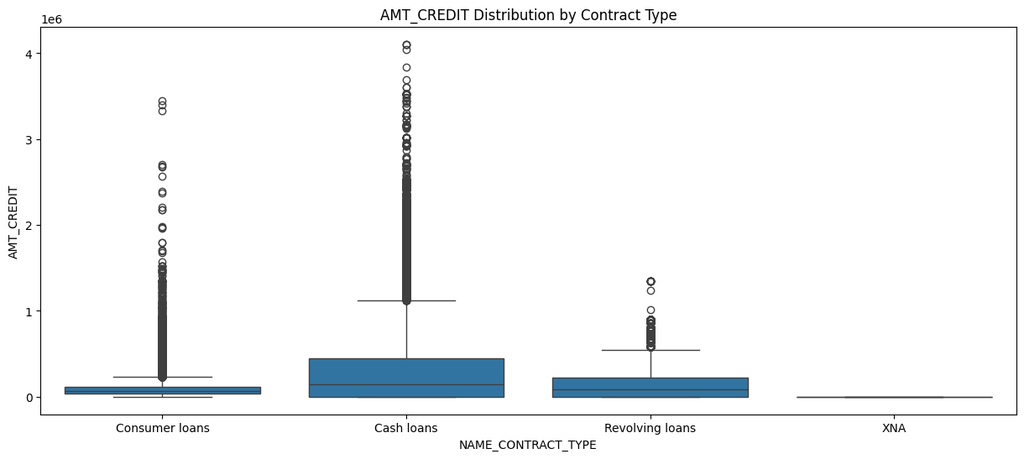

```python
plt.figure(figsize=(15, 6))
sns.boxplot(data=new_merged_df, x='NAME_CONTRACT_TYPE', y='AMT_CREDIT')
plt.title('AMT_CREDIT Distribution by Contract Type')
```

High AMT_CREDIT for some contract types suggests larger loans or financing options.

Wider spread indicates a broader range of credit amounts, possibly due to diverse customers or loan sizes.

Outliers may highlight exceptional cases, such as unusually large loans.

# Handelling in the null values with appropriate data.

```python
new_merged_df["AMT_ANNUITY"].median(),new_merged_df["AMT_ANNUITY"].mean()
```

```
(np.float64(11061.0), np.float64(15652.864966197689))
```

```python
new_merged_df["AMT_ANNUITY"] = new_merged_df["AMT_ANNUITY"].fillna(11061.0)
new_merged_df.head()
```

|  | NAME_CONTRACT_TYPE | AMT_ANNUITY | TARGET | AMT_CREDIT | AMT_DOWN_PAYMENT | AMT_GOODS_PRICE | NAME_CASH_LOAN_PURPOSE | NAME_INCOME_TYPE | NAME_HOUSING_TYPE | CODE_REJECT_REASON |
| --- | --- | --- | --- | --- | --- | --- | --- | --- | --- | --- |
| 0 | Consumer loans | 1730.430 | 1 | 17145.0 | 0.0 | 17145.0 | XAP | Working | House / apartment | XAP |
| 1 | Cash loans | 25188.615 | 0 | 679671.0 | NaN | 607500.0 | XNA | State servant | House / apartment | XAP |
| 2 | Cash loans | 15060.735 | 0 | 136444.5 | NaN | 112500.0 | XNA | Working | House / apartment | XAP |
| 3 | Cash loans | 47041.335 | 0 | 470790.0 | NaN | 450000.0 | XNA | Working | House / apartment | XAP |
| 4 | Cash loans | 31924.395 | 0 | 404055.0 | NaN | 337500.0 | Repairs | Working | House / apartment | HC |

```python
new_merged_df["AMT_DOWN_PAYMENT"].median(),new_merged_df["AMT_DOWN_PAYMENT"].mean()
```

```
(np.float64(1710.0), np.float64(6686.938290620594))
```

```python
new_merged_df["AMT_DOWN_PAYMENT"] = new_merged_df["AMT_DOWN_PAYMENT"].fillna(1710.0)
```

```python
new_merged_df["AMT_GOODS_PRICE"].median(),new_merged_df["AMT_GOODS_PRICE"].mean()
```

```
(np.float64(107955.0), np.float64(195516.80903944903))
```

```python
new_merged_df["AMT_GOODS_PRICE"] = new_merged_df["AMT_GOODS_PRICE"].fillna(107955.0)
```

```python
new_merged_df.info()
```

```
<class 'pandas.core.frame.DataFrame'>
RangeIndex: 307511 entries, 0 to 307510
Data columns (total 10 columns):
 #   Column                  Non-Null Count   Dtype
---  ------                  --------------   -----
 0   NAME_CONTRACT_TYPE      307511 non-null  object
 1   AMT_ANNUITY             307511 non-null  float64
 2   TARGET                  307511 non-null  int64
 3   AMT_CREDIT              307511 non-null  float64
 4   AMT_DOWN_PAYMENT        307511 non-null  float64
 5   AMT_GOODS_PRICE         307511 non-null  float64
 6   NAME_CASH_LOAN_PURPOSE  307511 non-null  object
 7   NAME_INCOME_TYPE        307511 non-null  object
 8   NAME_HOUSING_TYPE       307511 non-null  object
 9   CODE_REJECT_REASON      307511 non-null  object
dtypes: float64(4), int64(1), object(5)
memory usage: 23.5+ MB
```

```python
new_merged_df.describe(include='all')
```

|  | NAME_CONTRACT_TYPE | AMT_ANNUITY | TARGET | AMT_CREDIT | AMT_DOWN_PAYMENT | AMT_GOODS_PRICE | NAME_CASH_LOAN_PURPOSE | NAME_INCOME_TYPE | NAME_HOUSING_TYPE | CODE_REJECT_REASON |
| --- | --- | --- | --- | --- | --- | --- | --- | --- | --- | --- |
| count | 307511 | 307511.000000 | 307511.000000 | 3.075110e+05 | 3.075110e+05 | 3.075110e+05 | 307511 | 307511 | 307511 | 307511 |
| unique | 4 | NaN | NaN | NaN | NaN | NaN | 25 | 8 | 6 | 9 |
| top | Consumer loans | NaN | NaN | NaN | NaN | NaN | XAP | Working | House / apartment | XAP |
| freq | 139360 | NaN | NaN | NaN | NaN | NaN | 174617 | 158774 | 272868 | 249665 |
| mean | NaN | 14654.681495 | 0.080729 | 1.913551e+05 | 4.097809e+03 | 1.955168e+05 | NaN | NaN | NaN | NaN |
| std | NaN | 13063.848864 | 0.272419 | 3.126456e+05 | 1.372659e+04 | 2.757977e+05 | NaN | NaN | NaN | NaN |
| min | NaN | 0.000000 | 0.000000 | 0.000000e+00 | 0.000000e+00 | 0.000000e+00 | NaN | NaN | NaN | NaN |
| 25% | NaN | 7341.997500 | 0.000000 | 2.492100e+04 | 1.710000e+03 | 6.541650e+04 | NaN | NaN | NaN | NaN |
| 50% | NaN | 11061.000000 | 0.000000 | 7.920450e+04 | 1.710000e+03 | 1.079550e+05 | NaN | NaN | NaN | NaN |
| 75% | NaN | 16471.665000 | 0.000000 | 2.037600e+05 | 1.710000e+03 | 1.800000e+05 | NaN | NaN | NaN | NaN |
| max | NaN | 417927.645000 | 1.000000 | 4.104351e+06 | 1.964970e+06 | 3.935970e+06 | NaN | NaN | NaN | NaN |

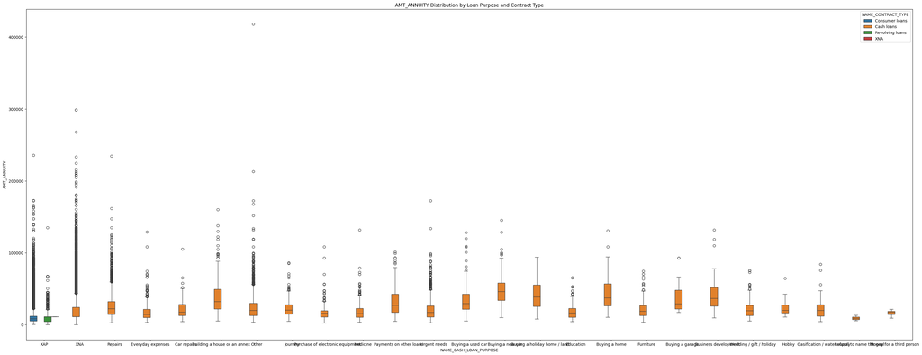

```python
plt.figure(figsize=(40,15))
sns.boxplot(data=new_merged_df, hue=new_merged_df["NAME_CONTRACT_TYPE"],y=new_merged_df["AMT_ANNUITY"],x=new_merged_df["NAME_CASH_LOAN_PURPOSE"])
plt.title('AMT_ANNUITY Distribution by Loan Purpose and Contract Type')
```

```python
graph_grpby = new_merged_df.groupby("NAME_CONTRACT_TYPE").size().reset_index(name='count')
graph_grpby.apply(lambda x : x)
```

|  | NAME_CONTRACT_TYPE | count |
| --- | --- | --- |
| 0 | Cash loans | 132894 |
| 1 | Consumer loans | 139360 |
| 2 | Revolving loans | 35202 |
| 3 | XNA | 55 |

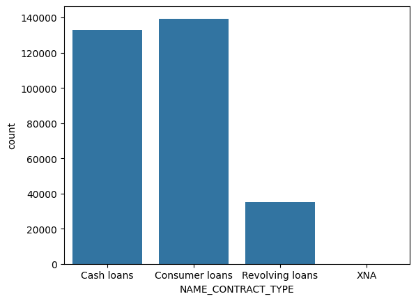

```python
sns.barplot(data=graph_grpby, x="NAME_CONTRACT_TYPE", y="count")
```

# From this graph, we can conclude that consumer loans have the highest number of applicants (139,360), followed closely by cash loans (132,894), while the XNA category has the least number of loans.

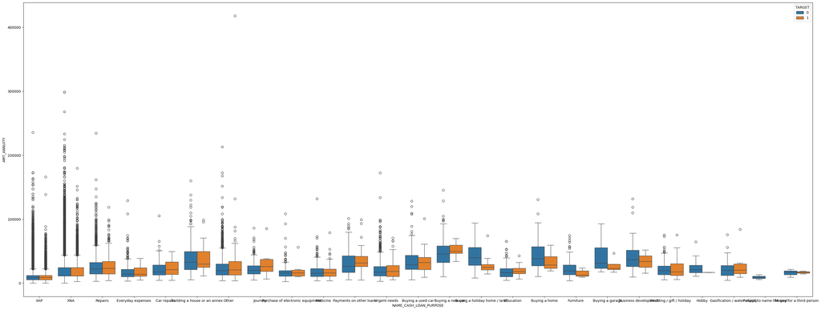

```python
plt.figure(figsize=(40,15))
sns.boxplot(data=new_merged_df, hue=new_merged_df["TARGET"],y=new_merged_df["AMT_ANNUITY"],x=new_merged_df["NAME_CASH_LOAN_PURPOSE"])
```

# For certain loan purposes, the annuity amounts vary significantly, with noticeable differences in medians and spreads.

# Outliers are present in several loan categories, suggesting that some applicants have unusually high or low annuity amounts.

# By comparing the repayment status (TARGET), we can analyze trends and identify which loan purposes may be more prone to default.

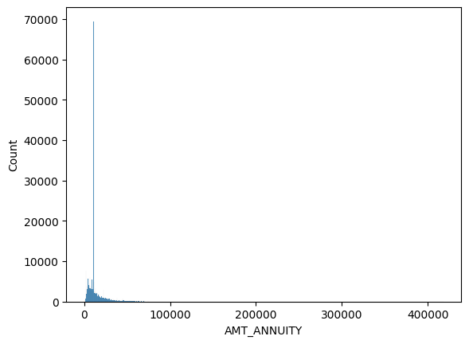

```python
sns.histplot(new_merged_df["AMT_ANNUITY"])
```

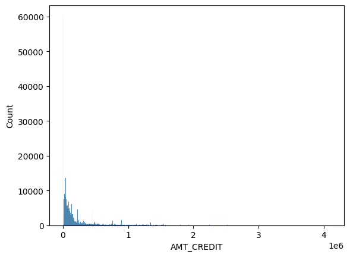

```python
sns.histplot(new_merged_df['AMT_CREDIT'])
```

```python
new_merged_df["AMT_CREDIT"].max()
```

```
np.float64(4104351.0)
```

```python
new_merged_df["AMT_CREDIT"].min()
```

```
np.float64(0.0)
```

```python
q1=np.percentile(new_merged_df['AMT_CREDIT'],25)
q1
```

```
np.float64(24921.0)
```

```python
q3=np.percentile(new_merged_df["AMT_CREDIT"],75)
q3
```

```
np.float64(203760.0)
```

```python
upper_fence = q3+1.5*(q3-q1)
upper_fence
```

```
np.float64(472018.5)
```

```python
lower_fence = q1-1.5*(q3-q1)
lower_fence
```

```
np.float64(-243337.5)
```

Lower fence can not be a negative value so we can take it as 0

```python
lower_fence = 0
```

```python
outlier = new_merged_df[(new_merged_df["AMT_CREDIT"] > upper_fence) | (new_merged_df["AMT_CREDIT"] < lower_fence)]
outlier
```

|  | NAME_CONTRACT_TYPE | AMT_ANNUITY | TARGET | AMT_CREDIT | AMT_DOWN_PAYMENT | AMT_GOODS_PRICE | NAME_CASH_LOAN_PURPOSE | NAME_INCOME_TYPE | NAME_HOUSING_TYPE | CODE_REJECT_REASON |
| --- | --- | --- | --- | --- | --- | --- | --- | --- | --- | --- |
| 1 | Cash loans | 25188.615 | 0 | 679671.0 | 1710.0 | 607500.0 | XNA | State servant | House / apartment | XAP |
| 20 | Cash loans | 25454.025 | 0 | 491580.0 | 1710.0 | 450000.0 | XNA | Working | House / apartment | HC |
| 23 | Cash loans | 39475.305 | 0 | 1277104.5 | 1710.0 | 1129500.0 | XNA | Pensioner | House / apartment | HC |
| 47 | Cash loans | 75897.630 | 0 | 2241513.0 | 1710.0 | 2025000.0 | XNA | Working | House / apartment | XAP |
| 56 | Cash loans | 49299.435 | 0 | 504711.0 | 1710.0 | 450000.0 | XNA | Pensioner | Municipal apartment | XAP |
| ... | ... | ... | ... | ... | ... | ... | ... | ... | ... | ... |
| 307482 | Cash loans | 32272.605 | 0 | 767664.0 | 1710.0 | 675000.0 | Other | Commercial associate | House / apartment | LIMIT |
| 307496 | Cash loans | 21687.750 | 0 | 536917.5 | 1710.0 | 463500.0 | XNA | Working | House / apartment | LIMIT |
| 307505 | Cash loans | 21521.880 | 0 | 663093.0 | 1710.0 | 553500.0 | XNA | Pensioner | House / apartment | HC |
| 307508 | Cash loans | 26316.945 | 0 | 491580.0 | 1710.0 | 450000.0 | XNA | Working | House / apartment | XAP |
| 307510 | Cash loans | 24277.320 | 0 | 533160.0 | 1710.0 | 450000.0 | XNA | Commercial associate | House / apartment | XAP |

34665 rows × 10 columns

```python
df_without_outlier = new_merged_df[(new_merged_df["AMT_CREDIT"] <= upper_fence) & (new_merged_df["AMT_CREDIT"] >= lower_fence)]
df_without_outlier
```

|  | NAME_CONTRACT_TYPE | AMT_ANNUITY | TARGET | AMT_CREDIT | AMT_DOWN_PAYMENT | AMT_GOODS_PRICE | NAME_CASH_LOAN_PURPOSE | NAME_INCOME_TYPE | NAME_HOUSING_TYPE | CODE_REJECT_REASON |
| --- | --- | --- | --- | --- | --- | --- | --- | --- | --- | --- |
| 0 | Consumer loans | 1730.430 | 1 | 17145.0 | 0.0 | 17145.0 | XAP | Working | House / apartment | XAP |
| 2 | Cash loans | 15060.735 | 0 | 136444.5 | 1710.0 | 112500.0 | XNA | Working | House / apartment | XAP |
| 3 | Cash loans | 47041.335 | 0 | 470790.0 | 1710.0 | 450000.0 | XNA | Working | House / apartment | XAP |
| 4 | Cash loans | 31924.395 | 0 | 404055.0 | 1710.0 | 337500.0 | Repairs | Working | House / apartment | HC |
| 5 | Cash loans | 23703.930 | 0 | 340573.5 | 1710.0 | 315000.0 | Everyday expenses | State servant | House / apartment | XAP |
| ... | ... | ... | ... | ... | ... | ... | ... | ... | ... | ... |
| 307503 | Cash loans | 5425.425 | 0 | 47970.0 | 1710.0 | 45000.0 | XNA | Commercial associate | House / apartment | XAP |
| 307504 | Revolving loans | 6750.000 | 0 | 135000.0 | 1710.0 | 107955.0 | XAP | Working | House / apartment | XNA |
| 307506 | Cash loans | 11061.000 | 0 | 0.0 | 1710.0 | 107955.0 | XNA | Working | With parents | XAP |
| 307507 | Cash loans | 18212.805 | 0 | 167895.0 | 1710.0 | 157500.0 | XNA | Pensioner | House / apartment | XAP |
| 307509 | Cash loans | 11061.000 | 1 | 0.0 | 1710.0 | 107955.0 | XNA | Commercial associate | House / apartment | XAP |

272846 rows × 10 columns

```python
df_without_outlier.info()
```

[output not shown]

```python
df_without_outlier = new_merged_df.copy()

for column in new_merged_df.select_dtypes(include=[np.number]).columns:
    if column != 'TARGET':
        q1 = np.percentile(new_merged_df[column], 25)
        q3 = np.percentile(new_merged_df[column], 75)
        iqr = q3 - q1
        lower_fence = q1 - 1.5 * iqr
        upper_fence = q3 + 1.5 * iqr
        df_without_outlier = df_without_outlier[
            (df_without_outlier[column] >= lower_fence) &
            (df_without_outlier[column] <= upper_fence)
        ]
print(f"Original data shape: {new_merged_df.shape}")
print(f"Data shape after removing outliers: {df_without_outlier.shape}")
```

```
Original data shape: (307511, 10)
Data shape after removing outliers: (118568, 10)
```

# Plot boxplots for each numerical column before removing outliers

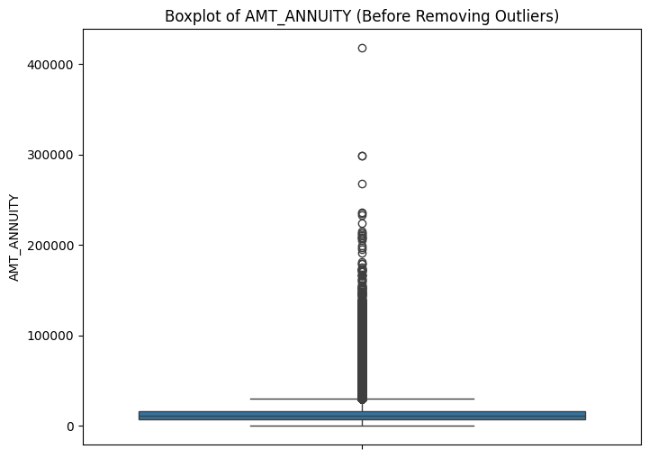

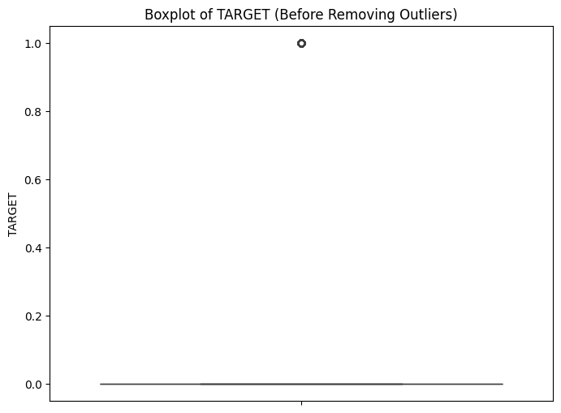

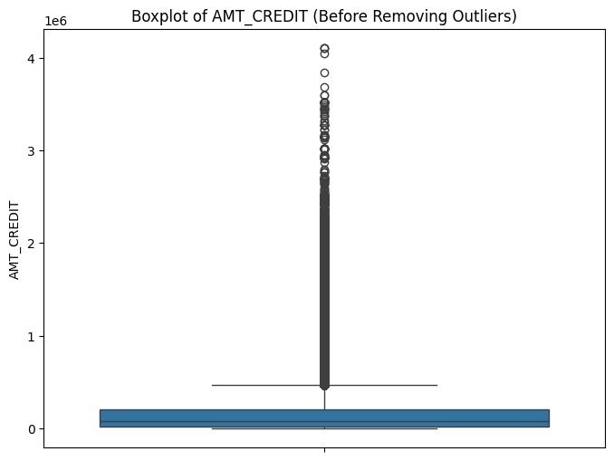

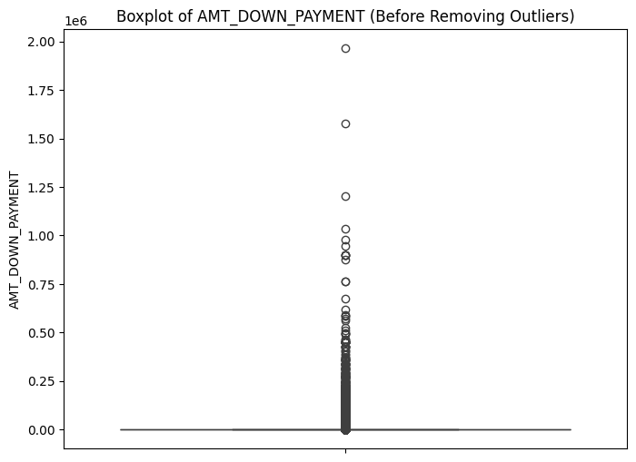

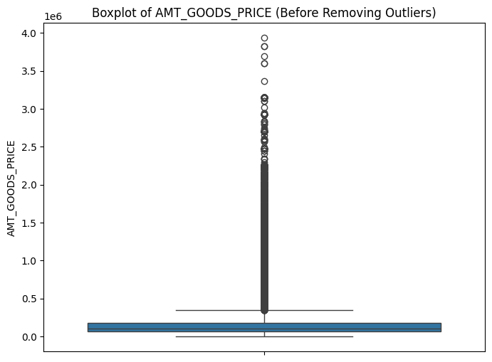

```python
for column in new_merged_df.select_dtypes(include=[np.number]).columns:
    plt.figure(figsize=(8, 6))
    sns.boxplot(y=new_merged_df[column])
    plt.title(f"Boxplot of {column} (Before Removing Outliers)")
    plt.show()
```

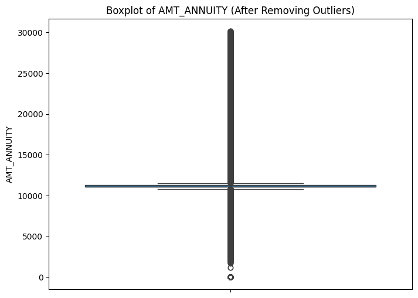

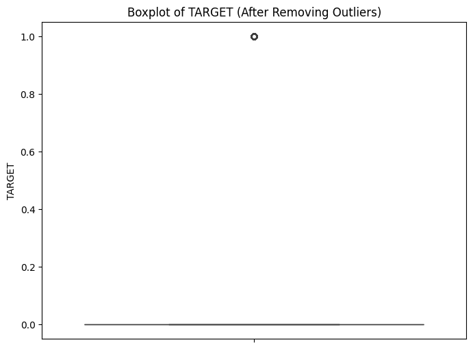

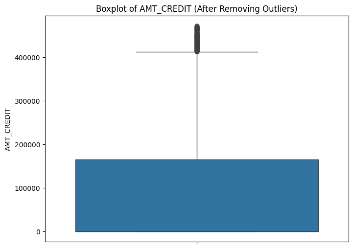

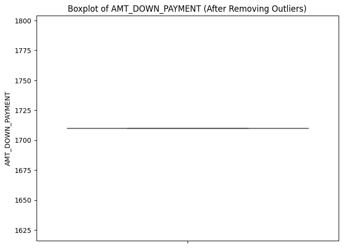

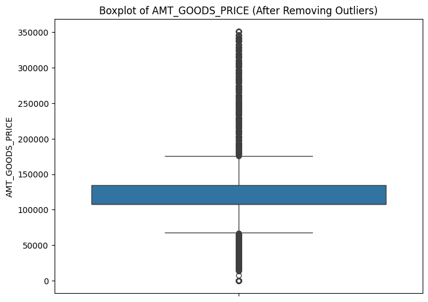

```python
for column in df_without_outlier.select_dtypes(include=[np.number]).columns:
    plt.figure(figsize=(8, 6))
    sns.boxplot(y=df_without_outlier[column])
    plt.title(f"Boxplot of {column} (After Removing Outliers)")
    plt.show()
```

```python
new_merged_df
```

|  | NAME_CONTRACT_TYPE | AMT_ANNUITY | TARGET | AMT_CREDIT | AMT_DOWN_PAYMENT | AMT_GOODS_PRICE | NAME_CASH_LOAN_PURPOSE | NAME_INCOME_TYPE | NAME_HOUSING_TYPE | CODE_REJECT_REASON |
| --- | --- | --- | --- | --- | --- | --- | --- | --- | --- | --- |
| 0 | Consumer loans | 1730.430 | 1 | 17145.0 | 0.0 | 17145.0 | XAP | Working | House / apartment | XAP |
| 1 | Cash loans | 25188.615 | 0 | 679671.0 | 1710.0 | 607500.0 | XNA | State servant | House / apartment | XAP |
| 2 | Cash loans | 15060.735 | 0 | 136444.5 | 1710.0 | 112500.0 | XNA | Working | House / apartment | XAP |
| 3 | Cash loans | 47041.335 | 0 | 470790.0 | 1710.0 | 450000.0 | XNA | Working | House / apartment | XAP |
| 4 | Cash loans | 31924.395 | 0 | 404055.0 | 1710.0 | 337500.0 | Repairs | Working | House / apartment | HC |
| ... | ... | ... | ... | ... | ... | ... | ... | ... | ... | ... |
| 307506 | Cash loans | 11061.000 | 0 | 0.0 | 1710.0 | 107955.0 | XNA | Working | With parents | XAP |
| 307507 | Cash loans | 18212.805 | 0 | 167895.0 | 1710.0 | 157500.0 | XNA | Pensioner | House / apartment | XAP |
| 307508 | Cash loans | 26316.945 | 0 | 491580.0 | 1710.0 | 450000.0 | XNA | Working | House / apartment | XAP |
| 307509 | Cash loans | 11061.000 | 1 | 0.0 | 1710.0 | 107955.0 | XNA | Commercial associate | House / apartment | XAP |
| 307510 | Cash loans | 24277.320 | 0 | 533160.0 | 1710.0 | 450000.0 | XNA | Commercial associate | House / apartment | XAP |

307511 rows × 10 columns

```python
df_without_outlier
```

|  | NAME_CONTRACT_TYPE | AMT_ANNUITY | TARGET | AMT_CREDIT | AMT_DOWN_PAYMENT | AMT_GOODS_PRICE | NAME_CASH_LOAN_PURPOSE | NAME_INCOME_TYPE | NAME_HOUSING_TYPE | CODE_REJECT_REASON |
| --- | --- | --- | --- | --- | --- | --- | --- | --- | --- | --- |
| 2 | Cash loans | 15060.735 | 0 | 136444.5 | 1710.0 | 112500.0 | XNA | Working | House / apartment | XAP |
| 5 | Cash loans | 23703.930 | 0 | 340573.5 | 1710.0 | 315000.0 | Everyday expenses | State servant | House / apartment | XAP |
| 6 | Cash loans | 11061.000 | 0 | 0.0 | 1710.0 | 107955.0 | XNA | Commercial associate | House / apartment | XAP |
| 7 | Cash loans | 11061.000 | 0 | 0.0 | 1710.0 | 107955.0 | XNA | State servant | House / apartment | XAP |
| 8 | Cash loans | 11061.000 | 0 | 0.0 | 1710.0 | 107955.0 | XNA | Pensioner | House / apartment | XAP |
| ... | ... | ... | ... | ... | ... | ... | ... | ... | ... | ... |
| 307503 | Cash loans | 5425.425 | 0 | 47970.0 | 1710.0 | 45000.0 | XNA | Commercial associate | House / apartment | XAP |
| 307504 | Revolving loans | 6750.000 | 0 | 135000.0 | 1710.0 | 107955.0 | XAP | Working | House / apartment | XNA |
| 307506 | Cash loans | 11061.000 | 0 | 0.0 | 1710.0 | 107955.0 | XNA | Working | With parents | XAP |
| 307507 | Cash loans | 18212.805 | 0 | 167895.0 | 1710.0 | 157500.0 | XNA | Pensioner | House / apartment | XAP |
| 307509 | Cash loans | 11061.000 | 1 | 0.0 | 1710.0 | 107955.0 | XNA | Commercial associate | House / apartment | XAP |

118568 rows × 10 columns

```python
numeric_columns = new_merged_df.select_dtypes(include=['float64', 'int64'])
```

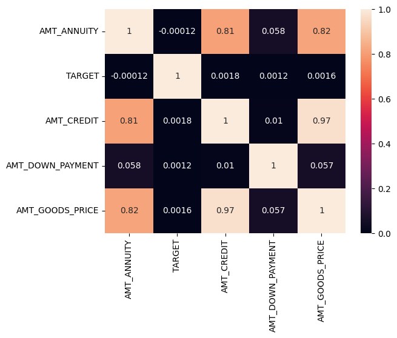

```python
sns.heatmap(data=numeric_columns.corr(), annot=True)
```

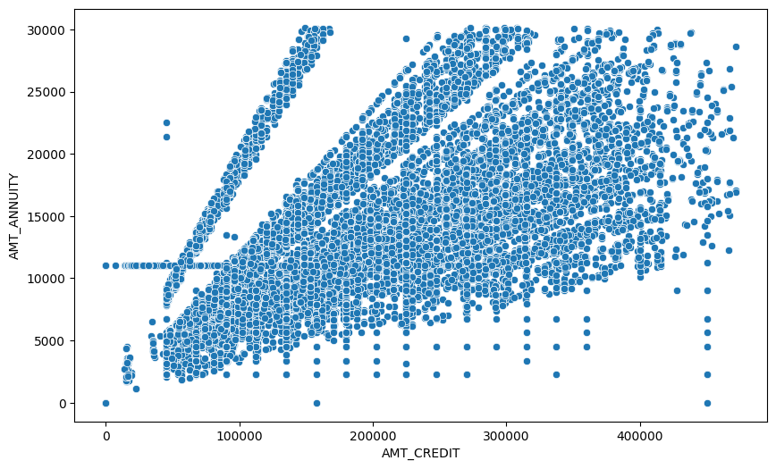

```python
plt.figure(figsize=(10, 6))
sns.scatterplot(y=df_without_outlier["AMT_ANNUITY"],x = df_without_outlier["AMT_CREDIT"])
plt.show()
```

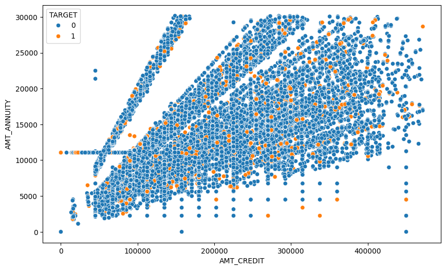

```python
plt.figure(figsize=(10, 6))
sns.scatterplot(y=df_without_outlier["AMT_ANNUITY"],x = df_without_outlier["AMT_CREDIT"],hue=df_without_outlier["TARGET"])
plt.show()
```

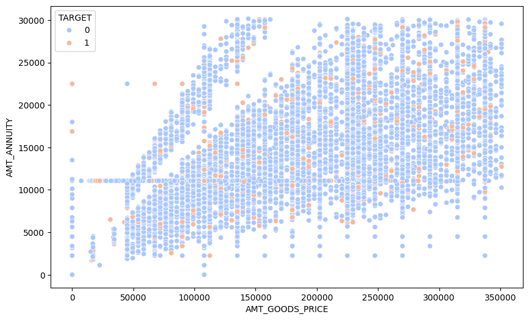

```python
plt.figure(figsize=(10, 6))
sns.scatterplot(y=df_without_outlier["AMT_ANNUITY"],x = df_without_outlier["AMT_GOODS_PRICE"],color='red',hue=df_without_outlier["TARGET"],palette="coolwarm")
```

```python
print(df_without_outlier["AMT_CREDIT"].describe())
```

```
count    118568.000000
mean      89663.382880
std      117344.109906
min           0.000000
25%           0.000000
50%           0.000000
75%      165226.500000
max      471703.500000
Name: AMT_CREDIT, dtype: float64
```

```python
print(df_without_outlier["AMT_DOWN_PAYMENT"].describe())
```

```
count    118568.0
mean       1710.0
std           0.0
min        1710.0
25%        1710.0
50%        1710.0
75%        1710.0
max        1710.0
Name: AMT_DOWN_PAYMENT, dtype: float64
```

# GROUPING THE DATA BASED ON NAME OF INCOME TYPE HERE WE ARE GOUPING THE THAT COLUMN TRY TO FIND HOW MUCH CREDIT BANK HAS GIVEN TO PRTICULAR INCOME PERSON

```python
income_group = df_without_outlier.groupby(by=["NAME_INCOME_TYPE"],as_index=False).agg({"AMT_CREDIT":"sum"})
income_group["AMT_CREDIT_MILL"] = income_group["AMT_CREDIT"]/100000
income_group
```

[output not shown]

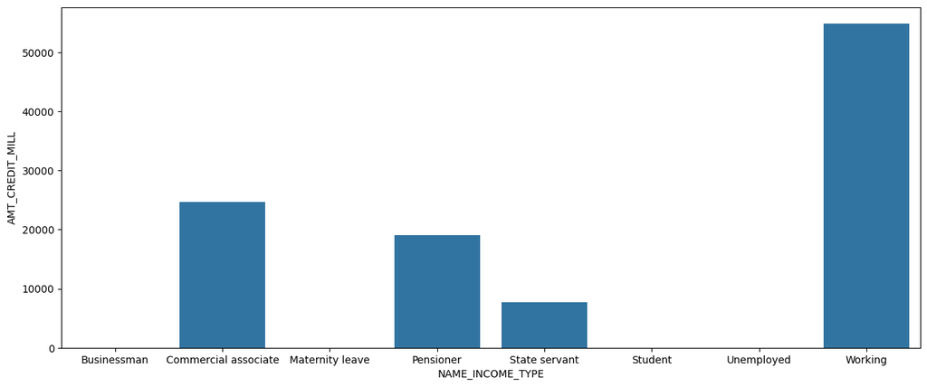

```python
plt.figure(figsize=(15, 6))
sns.barplot(x=income_group["NAME_INCOME_TYPE"], y=income_group["AMT_CREDIT_MILL"])
```

```python
income_group_ = df_without_outlier.groupby(by=["NAME_INCOME_TYPE"],as_index=False).agg({"AMT_DOWN_PAYMENT":"sum"})
income_group_["AMT_DOWN_PAYMENT_MILL"] = income_group_["AMT_DOWN_PAYMENT"]/100000
income_group_
```

|  | NAME_INCOME_TYPE | AMT_DOWN_PAYMENT | AMT_DOWN_PAYMENT_MILL |
| --- | --- | --- | --- |
| 0 | Businessman | 5130.0 | 0.0513 |
| 1 | Commercial associate | 47211390.0 | 472.1139 |
| 2 | Maternity leave | 1710.0 | 0.0171 |
| 3 | Pensioner | 36665820.0 | 366.6582 |
| 4 | State servant | 14475150.0 | 144.7515 |
| 5 | Student | 11970.0 | 0.1197 |
| 6 | Unemployed | 15390.0 | 0.1539 |
| 7 | Working | 104364720.0 | 1043.6472 |

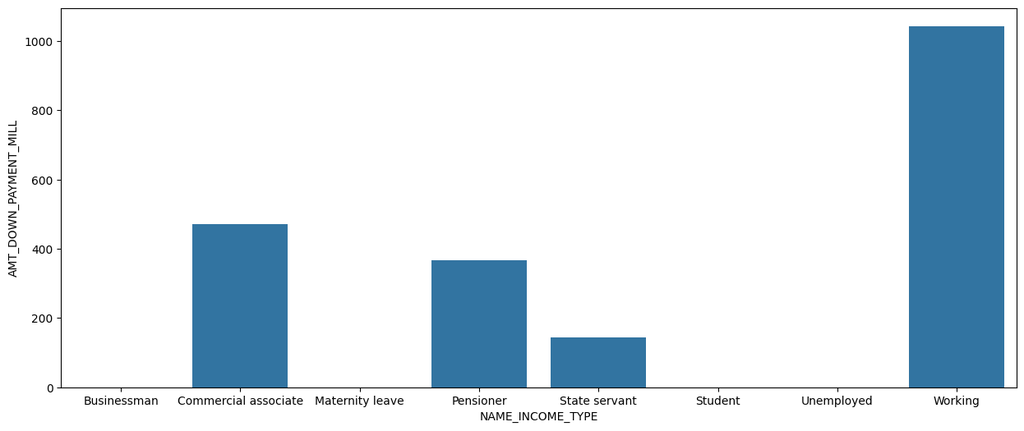

```python
plt.figure(figsize=(15, 6))
sns.barplot(x=income_group_["NAME_INCOME_TYPE"], y=income_group_["AMT_DOWN_PAYMENT_MILL"])
```

The data shows a clear relationship between income type and down payment amounts. Groups with higher down payments, such as Commercial Associates and Working individuals, demonstrate better financial stability or loan eligibility. On the other hand, groups with lower down payments, like Businessmen, Unemployed, and those on Maternity Leave, may face financial constraints or limited access to loans.

# HIGHER AMOUNT OF CREDIT WHO TAKE THAT LOAN WHICH ALSO REPAY THE LOAN HIGHEST AMOUNT

```python
# Calculating the proportion of down payment to credit for each income type
proportion_df = income_group_["AMT_DOWN_PAYMENT"] / income_group["AMT_CREDIT"]

proportion_df
```

```
0    0.011400
1    0.019144
2    0.009268
3    0.019251
4    0.018869
5    0.010928
6    0.023657
7    0.019007
dtype: float64
```

```python
# Group the data by Target and Income Type to decide whether to give loans again based on repayment behavior.
```

```python
new_grp_target = df_without_outlier.groupby(by=["TARGET","NAME_INCOME_TYPE","NAME_CONTRACT_TYPE"],as_index=False).agg({'AMT_CREDIT':'sum','AMT_DOWN_PAYMENT':'sum'})
new_grp_target.apply(lambda x:x)
```

|  | TARGET | NAME_INCOME_TYPE | NAME_CONTRACT_TYPE | AMT_CREDIT | AMT_DOWN_PAYMENT |
| --- | --- | --- | --- | --- | --- |
| 0 | 0 | Businessman | Cash loans | 0.000000e+00 | 3420.0 |
| 1 | 0 | Businessman | Revolving loans | 4.500000e+05 | 1710.0 |
| 2 | 0 | Commercial associate | Cash loans | 1.492498e+09 | 31833360.0 |
| 3 | 0 | Commercial associate | Consumer loans | 1.238007e+07 | 326610.0 |
| 4 | 0 | Commercial associate | Revolving loans | 7.693425e+08 | 11385180.0 |
| 5 | 0 | Commercial associate | XNA | 0.000000e+00 | 22230.0 |
| 6 | 0 | Maternity leave | Cash loans | 1.845000e+05 | 1710.0 |
| 7 | 0 | Pensioner | Cash loans | 1.194415e+09 | 25323390.0 |
| 8 | 0 | Pensioner | Consumer loans | 1.253336e+07 | 292410.0 |
| 9 | 0 | Pensioner | Revolving loans | 5.986125e+08 | 9033930.0 |
| 10 | 0 | Pensioner | XNA | 0.000000e+00 | 15390.0 |
| 11 | 0 | State servant | Cash loans | 4.764354e+08 | 10042830.0 |
| 12 | 0 | State servant | Consumer loans | 4.547254e+06 | 126540.0 |
| 13 | 0 | State servant | Revolving loans | 2.395800e+08 | 3483270.0 |
| 14 | 0 | State servant | XNA | 0.000000e+00 | 8550.0 |
| 15 | 0 | Student | Cash loans | 1.050336e+06 | 10260.0 |
| 16 | 0 | Student | Revolving loans | 4.500000e+04 | 1710.0 |
| 17 | 0 | Unemployed | Cash loans | 4.404150e+05 | 8550.0 |
| 18 | 0 | Working | Cash loans | 3.253863e+09 | 68743710.0 |
| 19 | 0 | Working | Consumer loans | 3.092862e+07 | 779760.0 |
| 20 | 0 | Working | Revolving loans | 1.669298e+09 | 24800130.0 |
| 21 | 0 | Working | XNA | 0.000000e+00 | 41040.0 |
| 22 | 1 | Commercial associate | Cash loans | 1.240564e+08 | 2669310.0 |
| 23 | 1 | Commercial associate | Consumer loans | 1.096466e+06 | 23940.0 |
| 24 | 1 | Commercial associate | Revolving loans | 6.669000e+07 | 950760.0 |
| 25 | 1 | Pensioner | Cash loans | 6.206394e+07 | 1436400.0 |
| 26 | 1 | Pensioner | Consumer loans | 9.479205e+05 | 20520.0 |
| 27 | 1 | Pensioner | Revolving loans | 3.609000e+07 | 543780.0 |
| 28 | 1 | State servant | Cash loans | 2.963250e+07 | 586530.0 |
| 29 | 1 | State servant | Consumer loans | 3.061980e+05 | 6840.0 |
| 30 | 1 | State servant | Revolving loans | 1.665000e+07 | 220590.0 |
| 31 | 1 | Unemployed | Cash loans | 2.101320e+05 | 6840.0 |
| 32 | 1 | Working | Cash loans | 3.501331e+08 | 7339320.0 |
| 33 | 1 | Working | Consumer loans | 3.307370e+06 | 85500.0 |
| 34 | 1 | Working | Revolving loans | 1.834200e+08 | 2568420.0 |
| 35 | 1 | Working | XNA | 0.000000e+00 | 6840.0 |

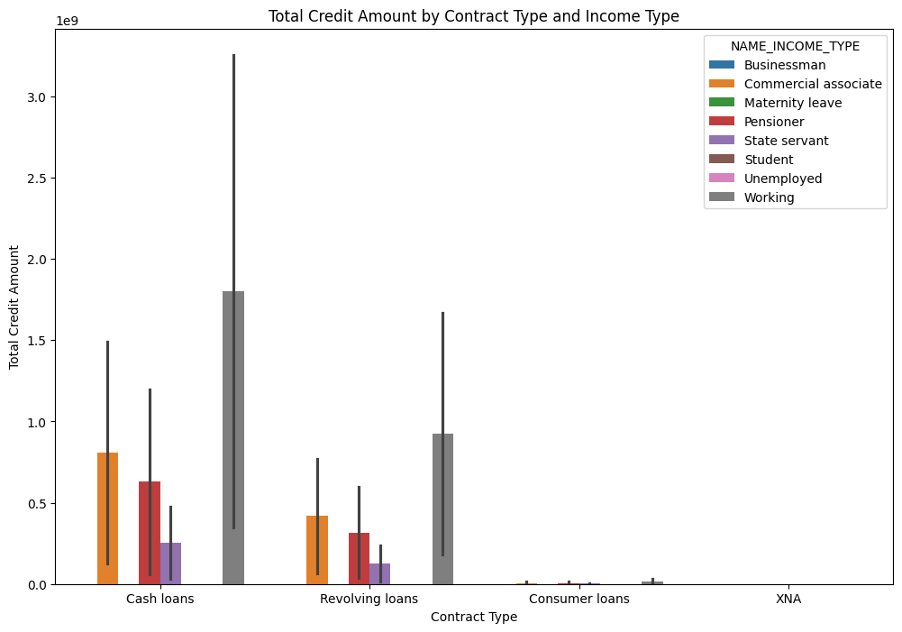

```python
plt.figure(figsize=(12, 8))
sns.barplot(x="NAME_CONTRACT_TYPE", y="AMT_CREDIT", data=new_grp_target, hue="NAME_INCOME_TYPE")
plt.xlabel("Contract Type")
plt.ylabel("Total Credit Amount")
plt.title("Total Credit Amount by Contract Type and Income Type")
plt.show()
```

You may notice outliers or unusual patterns in the data. For instance, certain contract types within income groups, such as Working or Commercial Associates, may show very high credit amounts. This could suggest outliers or specific business needs that require larger loan amounts.

```python
new_df = df_without_outlier.groupby(by=["NAME_CASH_LOAN_PURPOSE","TARGET"]).size().reset_index(name="count")
new_df.apply(lambda x:x)
```

|  | NAME_CASH_LOAN_PURPOSE | TARGET | count |
| --- | --- | --- | --- |
| 0 | Building a house or an annex | 0 | 94 |
| 1 | Building a house or an annex | 1 | 7 |
| 2 | Business development | 0 | 12 |
| 3 | Business development | 1 | 1 |
| 4 | Buying a garage | 0 | 4 |
| 5 | Buying a garage | 1 | 1 |
| 6 | Buying a holiday home / land | 0 | 17 |
| 7 | Buying a home | 0 | 10 |
| 8 | Buying a home | 1 | 4 |
| 9 | Buying a new car | 0 | 16 |
| 10 | Buying a used car | 0 | 88 |
| 11 | Buying a used car | 1 | 14 |
| 12 | Car repairs | 0 | 111 |
| 13 | Car repairs | 1 | 6 |
| 14 | Education | 0 | 120 |
| 15 | Education | 1 | 11 |
| 16 | Everyday expenses | 0 | 203 |
| 17 | Everyday expenses | 1 | 12 |
| 18 | Furniture | 0 | 94 |
| 19 | Furniture | 1 | 5 |
| 20 | Gasification / water supply | 0 | 26 |
| 21 | Gasification / water supply | 1 | 3 |
| 22 | Hobby | 0 | 8 |
| 23 | Hobby | 1 | 1 |
| 24 | Journey | 0 | 90 |
| 25 | Journey | 1 | 6 |
| 26 | Medicine | 0 | 209 |
| 27 | Medicine | 1 | 16 |
| 28 | Money for a third person | 0 | 2 |
| 29 | Money for a third person | 1 | 2 |
| 30 | Other | 0 | 1230 |
| 31 | Other | 1 | 100 |
| 32 | Payments on other loans | 0 | 90 |
| 33 | Payments on other loans | 1 | 7 |
| 34 | Purchase of electronic equipment | 0 | 95 |
| 35 | Purchase of electronic equipment | 1 | 4 |
| 36 | Refusal to name the goal | 0 | 3 |
| 37 | Repairs | 0 | 1724 |
| 38 | Repairs | 1 | 164 |
| 39 | Urgent needs | 0 | 1069 |
| 40 | Urgent needs | 1 | 85 |
| 41 | Wedding / gift / holiday | 0 | 96 |
| 42 | Wedding / gift / holiday | 1 | 11 |
| 43 | XAP | 0 | 29426 |
| 44 | XAP | 1 | 2589 |
| 45 | XNA | 0 | 74102 |
| 46 | XNA | 1 | 6580 |

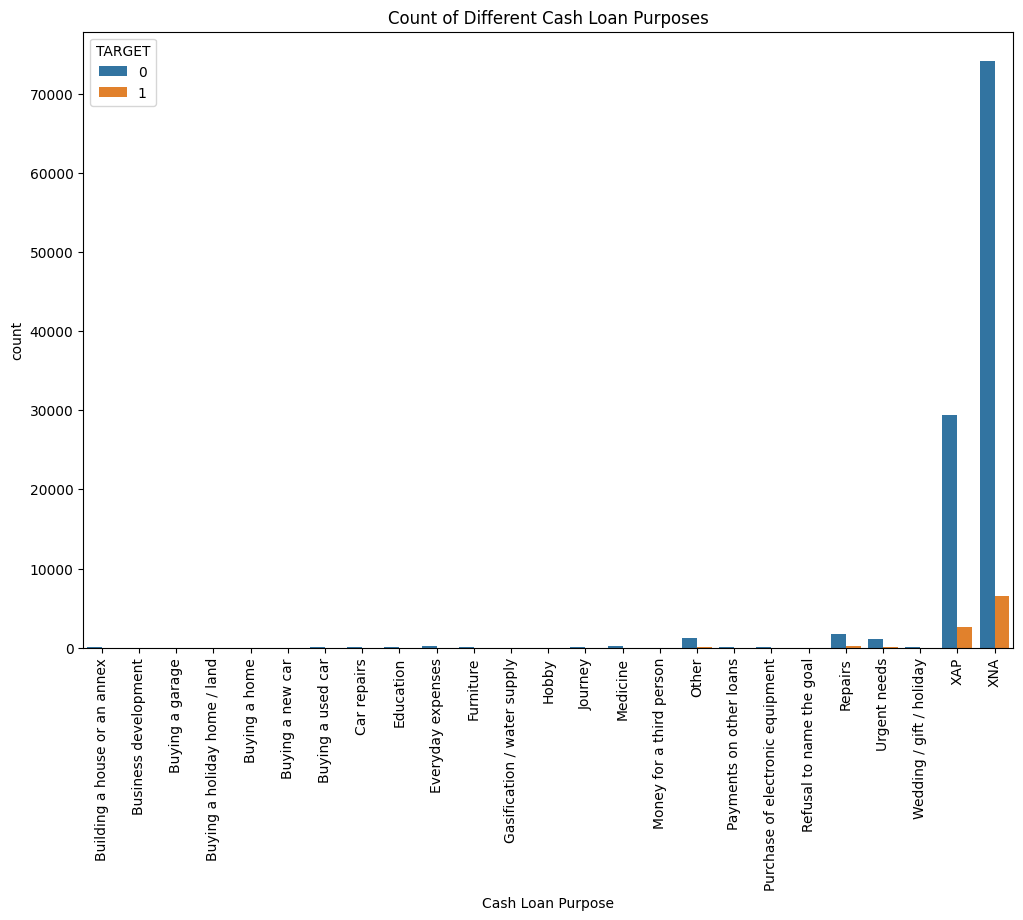

```python
plt.figure(figsize=(12, 8))
sns.barplot(x="NAME_CASH_LOAN_PURPOSE", y="count", data=new_df,hue="TARGET")
plt.xticks(rotation=90)
plt.xlabel("Cash Loan Purpose")
plt.title("Count of Different Cash Loan Purposes")
```

```python
df_without_outlier["TARGET"].value_counts()
```

```
TARGET
0    108939
1      9629
Name: count, dtype: int64
```

```python
df_without_outlier.shape
```

```
(118568, 10)
```

```python
df_without_outlier.head()
```

|  | NAME_CONTRACT_TYPE | AMT_ANNUITY | TARGET | AMT_CREDIT | AMT_DOWN_PAYMENT | AMT_GOODS_PRICE | NAME_CASH_LOAN_PURPOSE | NAME_INCOME_TYPE | NAME_HOUSING_TYPE | CODE_REJECT_REASON |
| --- | --- | --- | --- | --- | --- | --- | --- | --- | --- | --- |
| 2 | Cash loans | 15060.735 | 0 | 136444.5 | 1710.0 | 112500.0 | XNA | Working | House / apartment | XAP |
| 5 | Cash loans | 23703.930 | 0 | 340573.5 | 1710.0 | 315000.0 | Everyday expenses | State servant | House / apartment | XAP |
| 6 | Cash loans | 11061.000 | 0 | 0.0 | 1710.0 | 107955.0 | XNA | Commercial associate | House / apartment | XAP |
| 7 | Cash loans | 11061.000 | 0 | 0.0 | 1710.0 | 107955.0 | XNA | State servant | House / apartment | XAP |
| 8 | Cash loans | 11061.000 | 0 | 0.0 | 1710.0 | 107955.0 | XNA | Pensioner | House / apartment | XAP |

```python
df_without_outlier.info()
```

```
<class 'pandas.core.frame.DataFrame'>
Index: 118568 entries, 2 to 307509
Data columns (total 10 columns):
 #   Column                  Non-Null Count   Dtype
---  ------                  --------------   -----
 0   NAME_CONTRACT_TYPE      118568 non-null  object
 1   AMT_ANNUITY             118568 non-null  float64
 2   TARGET                  118568 non-null  int64
 3   AMT_CREDIT              118568 non-null  float64
 4   AMT_DOWN_PAYMENT        118568 non-null  float64
 5   AMT_GOODS_PRICE         118568 non-null  float64
 6   NAME_CASH_LOAN_PURPOSE  118568 non-null  object
 7   NAME_INCOME_TYPE        118568 non-null  object
 8   NAME_HOUSING_TYPE       118568 non-null  object
 9   CODE_REJECT_REASON      118568 non-null  object
dtypes: float64(4), int64(1), object(5)
memory usage: 10.0+ MB
```

Here, we are testing the null hypothesis to determine if there is a significant correlation between "AMT_CREDIT" and "AMT_ANNUITY" or not.

Null Hypothesis: There is no correlation (H₀: ρ = 0)

Alternative Hypothesis: There is a correlation (H₁: ρ ≠ 0)

```python
corr, p_value = pearsonr(df_without_outlier['AMT_CREDIT'], df_without_outlier['AMT_ANNUITY'])
print(f"Correlation coefficient: {corr}, p-value: {p_value}")
if p_value < 0.05:
    print("Reject null hypothesis & significant correlation")
else:
    print("Fail to reject null hypothesis & No significant correlation")
X = df_without_outlier['AMT_CREDIT']
y = df_without_outlier['AMT_ANNUITY']
X = sm.add_constant(X)
```

```
Correlation coefficient: 0.5582086128957918, p-value: 0.0
Reject null hypothesis & significant correlation
```

AMT_CREDIT: This is the total amount of credit or loan the individual has taken from the bank. AMT_ANNUITY: This is the annual payment amount (or the loan repayment) that the individual is required to make for the loan. The correlation coefficient of 0.558 means that as the loan amount (AMT_CREDIT) increases, the annual repayment amount (AMT_ANNUITY) also tends to increase, though the relationship is not perfectly linear (it's a moderate positive correlation).

Another null hypothesis between AMT_ANNUITY and AMT_GOODS_PRICE

```python
from scipy.stats import pearsonr
import statsmodels.api as sm
corr, p_value = pearsonr(df_without_outlier['AMT_ANNUITY'], df_without_outlier['AMT_GOODS_PRICE'])
print(f"Correlation coefficient: {corr}, p-value: {p_value}")
if p_value < 0.05:
    print("Reject null hypothesis: Significant correlation exists.")
else:
    print("Fail to reject null hypothesis: No significant correlation.")
X = df_without_outlier['AMT_ANNUITY']
y = df_without_outlier['AMT_GOODS_PRICE']
X = sm.add_constant(X)
```

```
Correlation coefficient: 0.6433532716217116, p-value: 0.0
Reject null hypothesis: Significant correlation exists.
```

The AMT_ANNUITY column represents the annual repayment amount for the loan, and AMT_GOODS_PRICE represents the total price of the goods purchased with the loan.

The correlation coefficient of 0.643 suggests a moderate positive relationship between the annual repayment (AMT_ANNUITY) and the total price of the goods (AMT_GOODS_PRICE). This means that as the price of the goods increases, the annual repayment amount also tends to increase.

Since the p-value is 0.0, which is less than 0.05, it indicates that this relationship is statistically significant. Therefore, we reject the null hypothesis, confirming that there is a meaningful and significant correlation between the two variables.

# Conclusion

These findings can help financial analysts understand the typical repayment behavior based on the loan amount. It suggests that loans with higher amounts are generally associated with higher repayments, aligning with logical financial expectations. This insight can be useful for verifying loan terms, assessing risks, and detecting any discrepancies or fraud in loan applications. By evaluating this relationship, banks and lenders can improve their loan approval processes, ensuring that loan amounts and repayments are appropriately aligned.